# Data challenge Section 1 asset 2

May 1, 2020

### Case Fatality Rate (CFR) of COVID-19

By May 2020, more than 1 million of confirmed COVID-19 cases and 60k deaths have been reported by the Johns Hopkins University Coronavirus Resources Center. The early detection of the most relevant factors of deaths due to COVID-19 on U.S. county-level can aid in making decisions on lifestyle changes in high risk patients, distribution of public resources, and in turn reduce the CFR. This study aims to explore the most relevant health factors related to COVID-19 deaths as well as predict the overall risk using logistic regression.

The case fatality rate (CFR) will be used to measure the risk of dying from COVID-19, which is defined as
$$\frac{\text{number of deaths from disease}}{\text{number of diagnosed cases of disease}}$$

One of our primary interests is to predict COVID-19 death and pinpoint the most relevant factors of it. Logistic regression is usually used for prediction of outcome of a binomial dependent variable from a set of predictors. Logistic regression will also provide the risk of dying from COVID-19 measured by CFR.

### Data Cleaning and Preparation

This project involves two different datasets: one includes COVID-19 cases and deaths, another one includes health-related factors on county levels.

- `04-04-2020.csv.gz`: The COVID-19 data contain information about confirmed cases and deaths on 2020-04-04; retrieved from [Johns Hopkins COVID-19 data repository](https://github.com/CSSEGISandData/COVID-19). It is avaliable from this [link](https://github.com/CSSEGISandData/COVID-19) (commit 0174f38).
- `us-county-health-rankings-2020.csv.gz`: The 2020 County Health Ranking Data was released by [County Health Rankings](https://www.countyhealthrankings.org). The data is avaliable from the [Kaggle Uncover COVID-19 Challenge](https://www.kaggle.com/roche-data-science-coalition/uncover) (version 1).

Since both dataset contain various information on COVID-19 and we may not be interested in some of the variables, we will first perform necessary data cleaning to only include the desired variables.

Below is the final dataframe for future analysis:

```
##     county            confirmed           deaths                    state
##  Length:1446        Min.   :    5.0   Min.   :   0.000   Georgia       :  96
##  Class :character   1st Qu.:    9.0   1st Qu.:   0.000   Texas         :  80
##  Mode  :character   Median :   20.0   Median :   0.000   North Carolina:  63
##                     Mean   :  207.2   Mean   :   4.854   Mississippi   :  61
##                     3rd Qu.:   66.0   3rd Qu.:   2.000   Indiana       :  58
##                     Max.   :63306.0   Max.   :1905.000   Ohio          :  57
##                                                          (Other)       :1031
##  percent_fair_or_poor_health percent_smokers  percent_adults_with_obesity
##  Min.   : 8.121              Min.   : 5.909   Min.   :12.40
##  1st Qu.:14.390              1st Qu.:14.899   1st Qu.:29.10
##  Median :17.010              Median :17.143   Median :32.90
##  Mean   :17.594              Mean   :17.151   Mean   :32.39
##  3rd Qu.:20.398              3rd Qu.:19.365   3rd Qu.:36.20
##  Max.   :38.887              Max.   :27.775   Max.   :51.00
##
##  percent_with_access_to_exercise_opportunities percent_excessive_drinking
##  Min.   :  0.00                                Min.   : 7.81
##  1st Qu.: 59.95                                1st Qu.:15.68
##  Median : 74.71                                Median :18.03
##  Mean   : 71.15                                Mean   :17.91
##  3rd Qu.: 85.97                                3rd Qu.:20.01
##  Max.   :100.00                                Max.   :28.62
##
##  percent_adults_with_diabetes percent_insufficient_sleep
##  Min.   : 1.80                Min.   :23.03
##  1st Qu.: 9.10                1st Qu.:31.42
##  Median :11.30                Median :34.02
##  Mean   :11.75                Mean   :33.88
##  3rd Qu.:13.90                3rd Qu.:36.54
##  Max.   :34.10                Max.   :46.71
##
##  percent_less_than_18_years_of_age percent_65_and_over percent_black
##  Min.   : 7.069                    Min.   : 7.722      Min.   : 0.1286
##  1st Qu.:20.326                    1st Qu.:14.913      1st Qu.: 1.6168
##  Median :22.182                    Median :17.225      Median : 5.6397
##  Mean   :22.204                    Mean   :17.512      Mean   :12.4056
##  3rd Qu.:24.019                    3rd Qu.:19.598      3rd Qu.:17.4904
##  Max.   :35.447                    Max.   :57.587      Max.   :81.9544
##
##  percent_asian      percent_hispanic  percent_female
##  Min.   : 0.06245   Min.   : 0.7952   Min.   :34.63
##  1st Qu.: 0.68228   1st Qu.: 2.9451   1st Qu.:50.00
##  Median : 1.22863   Median : 5.6100   Median :50.65
##  Mean   : 2.40009   Mean   :10.0338   Mean   :50.46
##  3rd Qu.: 2.66813   3rd Qu.:11.1199   3rd Qu.:51.35
##  Max.   :42.95231   Max.   :96.3595   Max.   :56.87
##
```

### Logistic Regression Assumption Check

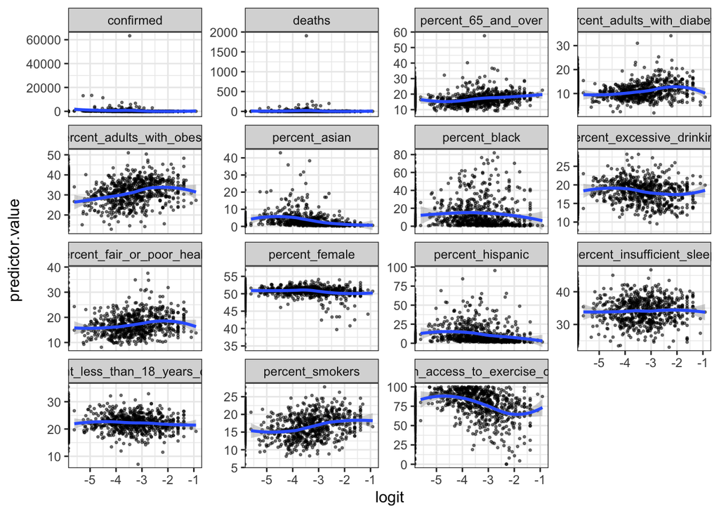

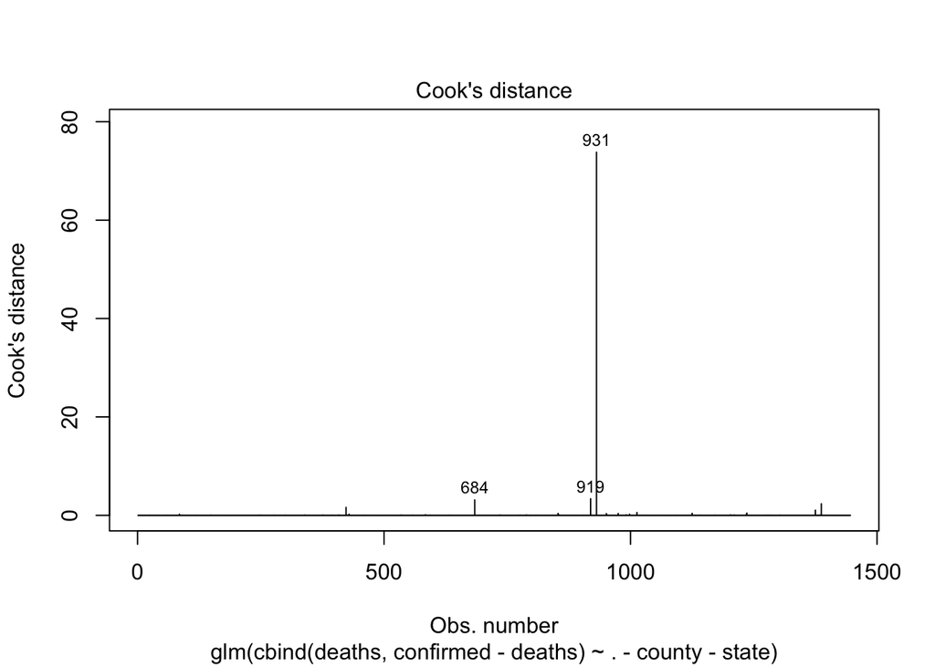

### Prediction: Logistic Regression

Again, one of our primary interests is to predict COVID-19 death and pinpoint the most relevant factors of it. Logistic regression is usually used for prediction of outcome of a binomial dependent variable from a set of predictors. Logistic regression will also provide the risk of dying from COVID-19 measured by CFR.

| **Characteristic** | **OR** | **95% CI** | **p-value** |
| --- | --- | --- | --- |
| **percent_asian** | 1.03 | 1.02, 1.03 | **<0.001** |
| **percent_less_than_18_years_of_age** | 0.94 | 0.93, 0.96 | **<0.001** |
| **percent_hispanic** | 0.99 | 0.98, 0.99 | **<0.001** |
| **percent_fair_or_poor_health** | 1.05 | 1.03, 1.07 | **<0.001** |
| **percent_adults_with_obesity** | 1.03 | 1.02, 1.04 | **<0.001** |
| **(Intercept)** | 0.03 | 0.00, 0.21 | **<0.001** |
| **percent_insufficient_sleep** | 0.99 | 0.98, 1.00 | 0.054 |
| **percent_65_and_over** | 0.99 | 0.97, 1.00 | 0.060 |
| **percent_with_access_to_exercise_opportunities** | 1.00 | 1.00, 1.01 | 0.10 |
| **percent_smokers** | 0.99 | 0.96, 1.01 | 0.2 |
| **percent_excessive_drinking** | 1.01 | 0.99, 1.02 | 0.3 |
| **percent_adults_with_diabetes** | 1.01 | 0.98, 1.03 | 0.5 |
| **percent_black** | 1.00 | 1.00, 1.00 | 0.6 |
| **percent_female** | 1.00 | 0.96, 1.03 | 0.9 |

### Goodness of fit check

After obtaining the model, we would like to know if it is the most edquate model for both describing our data and generalizing to other data. Goodness of fit check help us understand how well the logistic model fitting the data by comparing deviance between (a) our model vs saturated model and (b) our model vs null/intercept-only model.

```
## [1] 2.016365e-96
```

```
## [1] 4.686181e-79
```

1. For the comparison of the saturated model, the goodness of fit test results in a small p-value, in which we reject the $H_o$ and conclude that our logistic model provides poorer fit than the saturated model.
2. For the comparison of the null model, the goodness of fit test results in a small p-value, in which we reject the $H_o$ and conclude that our logistic model provides a better fit than the intercept-only model here.

In conclusion, our model explains some of the important features of COVID-19 death rate, but there is a room for improvement to fit the data better. Therefore, we would like to try implement some model selection methods.

Based on the analysis of deviance, the 5 most significant predictors are shown below

|  | Df | Deviance | AIC | LRT | Pr(>Chi) |
| --- | --- | --- | --- | --- | --- |
| percent_asian | 1 | 2912.111 | 4820.004 | 62.38003 | 0.0e+00 |
| percent_less_than_18_years_of_age | 1 | 2908.062 | 4815.956 | 58.33191 | 0.0e+00 |
| percent_hispanic | 1 | 2889.345 | 4797.238 | 39.61404 | 0.0e+00 |
| percent_fair_or_poor_health | 1 | 2870.829 | 4778.723 | 21.09870 | 4.4e-06 |
| percent_adults_with_obesity | 1 | 2870.424 | 4778.317 | 20.69325 | 5.4e-06 |

### Model Selection

The following methods will be implemented with different approaches and focus: (a) Akaike information criterion (AIC) (b) lasso with cross validation.

Perform sequential search using AIC.  
The best sub-model given by the AIC criterion is:

| **Characteristic** | **OR**<sup>1</sup> | **95% CI**<sup>1</sup> | **p-value** |
| --- | --- | --- | --- |
| (Intercept) | 0.04 | 0.02, 0.06 | <0.001 |
| percent_asian | 1.03 | 1.02, 1.03 | <0.001 |
| percent_less_than_18_years_of_age | 0.94 | 0.93, 0.95 | <0.001 |
| percent_hispanic | 0.99 | 0.98, 0.99 | <0.001 |
| percent_fair_or_poor_health | 1.04 | 1.03, 1.05 | <0.001 |
| percent_adults_with_obesity | 1.03 | 1.02, 1.04 | <0.001 |
| percent_insufficient_sleep | 0.99 | 0.98, 1.00 | 0.007 |
| percent_65_and_over | 0.99 | 0.98, 1.00 | 0.022 |
| percent_with_access_to_exercise_opportunities | 1.00 | 1.00, 1.01 | 0.11 |

<sup>*1*</sup> OR = Odds Ratio, CI = Confidence Interval

The model given by lasso with cross validation (using the AUC criteria) suggest to include all the predictor in the model, which is similar as the initial logistic model.

| **Characteristic** | **OR**<sup>1</sup> | **95% CI**<sup>1</sup> | **p-value** |
| --- | --- | --- | --- |
| percent_asian | 1.03 | 1.02, 1.03 | <0.001 |
| percent_less_than_18_years_of_age | 0.94 | 0.93, 0.96 | <0.001 |
| percent_hispanic | 0.99 | 0.98, 0.99 | <0.001 |
| percent_fair_or_poor_health | 1.05 | 1.03, 1.07 | <0.001 |
| percent_adults_with_obesity | 1.03 | 1.02, 1.04 | <0.001 |
| (Intercept) | 0.03 | 0.00, 0.21 | <0.001 |
| percent_insufficient_sleep | 0.99 | 0.98, 1.00 | 0.054 |
| percent_65_and_over | 0.99 | 0.97, 1.00 | 0.060 |
| percent_with_access_to_exercise_opportunities | 1.00 | 1.00, 1.01 | 0.10 |
| percent_smokers | 0.99 | 0.96, 1.01 | 0.2 |
| percent_excessive_drinking | 1.01 | 0.99, 1.02 | 0.3 |
| percent_adults_with_diabetes | 1.01 | 0.98, 1.03 | 0.5 |
| percent_black | 1.00 | 1.00, 1.00 | 0.6 |
| percent_female | 1.00 | 0.96, 1.03 | 0.9 |

<sup>*1*</sup> OR = Odds Ratio, CI = Confidence Interval

While each model emphasizes different aspect of analyzing the data, several predictors are consistently significant acroos all models.

### Interpretations

The following variables are the most significant county-level predictors to COVID-19 CFR, suggested by the models.

- For one unit increase in the percentage of Asian, the odds of dying from COVID-19 increased by 1.03, or 3%, holding all other features constant.
- Similarily, for one unit increase in the percentage of less than 18 years old, the odds of dying from COVID-19 reduced by 6%.
- For one unit increase in the percentage of hispanic, the odds of dying from COVID-19 reduced by 1%.
- For one unit increase in the percentage of people have fair or poor health, the odds of dying from COVID-19 increaed by 5%.
- For one unit increase in the percentage of adults with obesity, the odds of dying from COVID-19 increaed by 3%.

### Potential Limitations

The potential limitation of the study is discussed from 3 aspects;

- 1. CFR measurement
- 2. Unselected predictors
- 3. Logistic assumption violation
1. CFR measurement
   Again, CFR is defined as:
   $$\frac{\text{number of deaths from disease}}{\text{number of diagnosed cases of disease}}.$$
   Note that there are some limitations on using CFR to measure COVID-19 deaths rate. CFR assumes the reported deaths and confirmed cases are reflecting the actual information associated with the disease. COVID-19 has prolonged progression and lasts longer than other acute disease. During the long duration from being diagnosed to death, people is likely to die from another disease but still be counted as death due to COVID-19, which leads to an overestimate CFR. It would be more accurate to include this timeframe into the calculation. Similarly, when people actually died from COVID-19 before being confirmed and recorded, CFR will be underestimated.
2. Unselected predictors  
   There are other county-level variables, such as education and SES status, have not been included in the analysis. future analysis may want to include these variables and control for these effects.
3. Logistic assumption violation  
   The identical or independent assumptions of logistic regression may be violated. In this dataset, people are grouped as clusters, which can also lead to undetected heterogeneity and violate the identical assumption, e.g. people from certain places are easier to be affected with COVID-19. There may also be undetected dependence between trials. For example, healthcare resources may be increased by the death of the others, thus, CFRs are correlated. This will lead to a violation on the independent assumption. Both types of violations can lead to inflation of variance.

More studies are encouraged to address these limitations with more available COVID-19 data in the future.